# 11-mvn.md

Zhengqi Tian

```r
library("mvtnorm")
library("tidyverse")
```

In this blog post, I am going to perform a power and sample size calculation for a collaborator who is submitting a grant application to fund a study to show that two measurements are highly correlated. Reviewers of the grant want to fund studies that have a high likelihood of success, which in this setting is conclusively demonstrating that the correlation between A and B is greater than 0.8.

The researcher will collect both measurements on N individuals. The analysis will proceed by calculating a one-sided confidence interval. If the confidence interval is completely within the range from 0.8 to 1, then the researcher will consider the study to be a success: A conclusive demonstration that the correlation between A and B is greater than 0.8.

Power is the probability that the study will end in success when the true underlying correlation is, in fact, greater than 0.8. (Note the connection to Type II error (β): power = 1 - β.) Your collaborator needs you to estimate power for different combinations of sample size and the true population correlation. Let the sample size be 25, 50, 75, and 100. Let the population correlation range from 0.8 to 0.95.

The code below provides the power calculation for a single combination of N and population correlation.

```r
set.seed(20394)
suppressPackageStartupMessages(require(mvtnorm))
N <- 50
rho <- .8
null_correlation <- 0.8
R <- 5000

sigma <- array(c(1,rho,rho,1), c(2,2))
mu <- c(0,0)

detect <- rep(NA, R)
for(i in 1:R){
  data <- rmvnorm(N, mean = mu, sigma = sigma)
  results <- cor.test(x = data[,1], y = data[,2], alternative = "greater")
  detect[i] <- results$conf.int[1] > null_correlation
}
power <- mean(detect)
```

As we have the pwoer calculation for a single combination, the next step is to run a simulation based on changing sample size and true population correlation. To do that we can setup a function based on the pervious single calculation. Here we name the fucntion called power, with two input, N, sample size and rho, tru population correlation. We keep the null correaltion as 0.8, R as 5000 as will. to use rmonorm(), we need simulate sigma, and mu first. Then we can use rmvnorm to simulate the data. As the data is avaliable, we can have the result.

```r
power= function(N, rho){
  null_correlation <- 0.8
  R <- 5000
  power = NA
  for(i in 1:length(rho)) {
    sigma <- array(c(1,rho[i],rho[i],1), c(2,2))
    mu <- c(0,0)

    detect <- rep(NA, R)
    for(j in 1:R){
      data <- rmvnorm(N[i], mean = mu, sigma = sigma)
      results <- cor.test(x = data[,1], y = data[,2], alternative = "greater")
      detect[j] <- results$conf.int[1] > null_correlation
    }
    power[i] <- mean(detect)
  }
  return(power)
}
```

With the power function, we are able to find power for certain sample size and true population correlation. Here we loook for sample size as 25,50,75, and 100. the true population correlation from 0.8.0.95. We expand. grid() we can add these two list with power for power matrix. Since we have sample size and true population correlation. powerfunction is able to calculate all required power result.

```r
# Sample Size
N <- c(25, 50, 75, 100)

# True population correlation
rho <- seq(0.8, 0.96, by = 0.01)

powermatrix <- expand.grid(N = N, rho = rho, power=NA)

for(i in 1:nrow(powermatrix)) {
  powermatrix[i,3] = power(N = powermatrix[i,1], rho = powermatrix[i,2])
}
powermatrix
```

```
##      N  rho  power
## 1   25 0.80 0.0588
## 2   50 0.80 0.0552
## 3   75 0.80 0.0576
## 4  100 0.80 0.0556
## 5   25 0.81 0.0748
## 6   50 0.81 0.0806
## 7   75 0.81 0.0858
## 8  100 0.81 0.0906
## 9   25 0.82 0.0952
## 10  50 0.82 0.1150
## 11  75 0.82 0.1288
## 12 100 0.82 0.1488
## 13  25 0.83 0.1248
## 14  50 0.83 0.1634
```

[output cut: 54 more lines]

Now, as we have all data, we can use ggplot the have the plot.

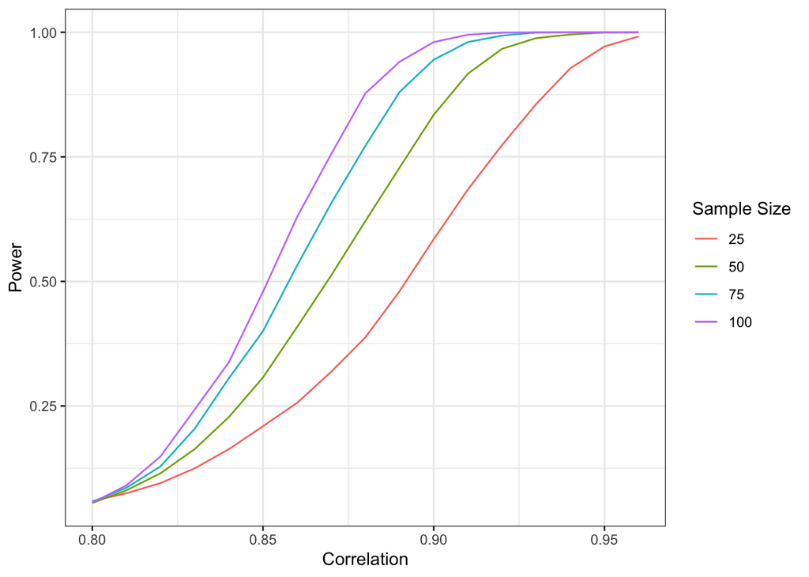

```r
powermatrix%>%
  ggplot(aes(x = rho, y = power, col = factor(N))) +
  geom_line() +
  theme_bw() +
  labs(x = "Correlation",
       y = "Power",
       color= "Sample Size")
```